# E2. Preparación y Modelado de los datos

##### Visualización

**Comparison Age Histogram**

En la grafica podemos ver que las edades que mas predominan son entre los 20-40. Esto para la base de datos general y para la filtrada por fraude

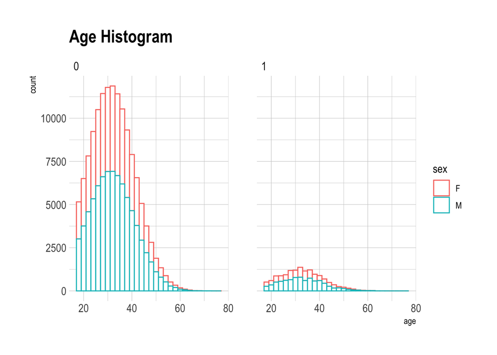

**Comparison Purchase Value Histogram**

En la grafica podemos ver que en la base de datos las cantidades que mas gastan son entre los 20 a 60 (pico de $35) dolares.

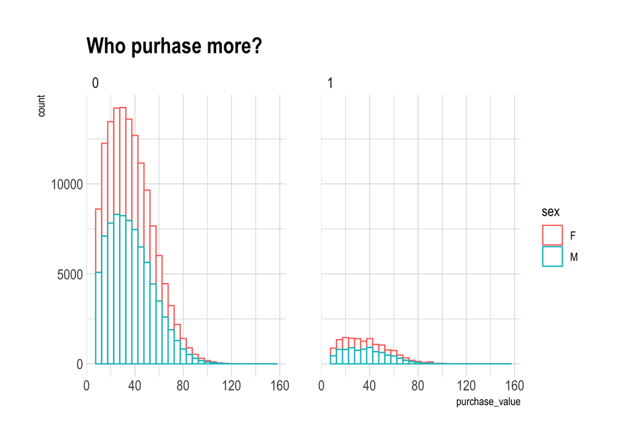

**Schedule x purchase value Boxplot**

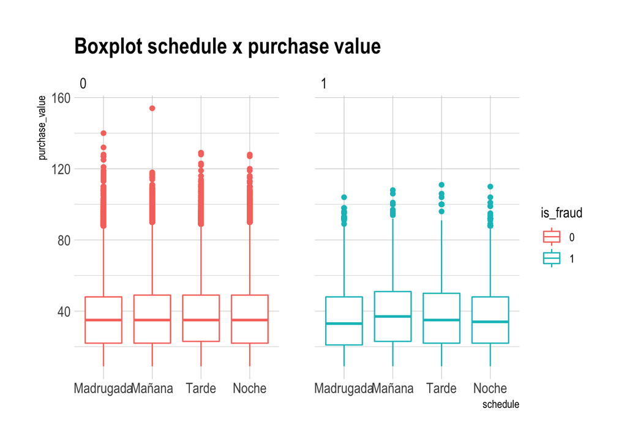

**Source x purchase value Boxplot**

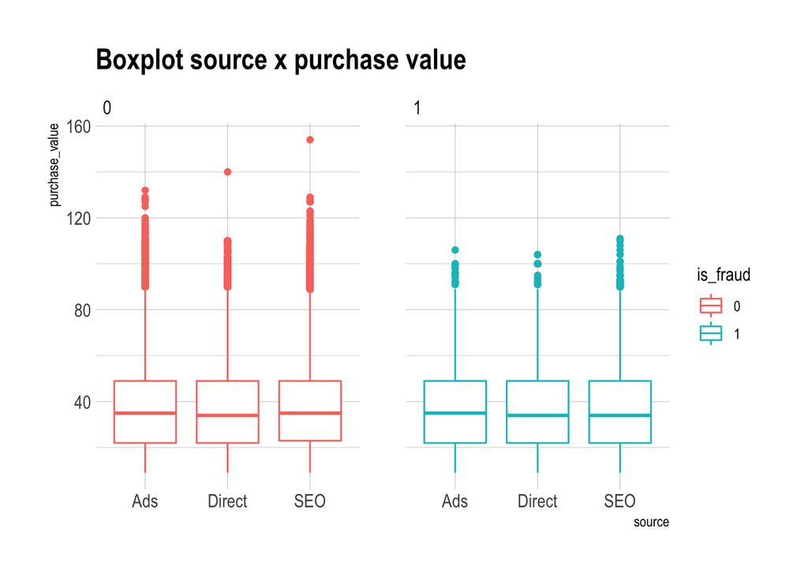

```r
Devicedata %>%
  ggplot(aes(x = source, y = purchase_value, color = is_fraud)) +
  geom_boxplot() +
  facet_wrap(~is_fraud, ncol = 3) +
  labs (title = "Boxplot source x purchase value") +
  hrbrthemes::theme_ipsum()
```

**Browser x purchase value Boxplot**

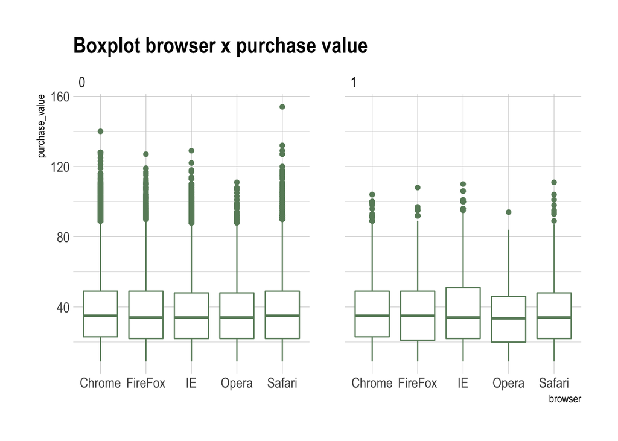

```r
Devicedata %>%
  ggplot(aes(x = browser, y = purchase_value, color = is_fraud)) +
  geom_boxplot(color = "darkseagreen4") +
  facet_wrap(~is_fraud, ncol = 3) +
  labs (title = "Boxplot browser x purchase value") +
  hrbrthemes::theme_ipsum()
```

**————————————————————————————————-**

#### **3. Transaction Dataset**

```r
TransactionData <- read_csv("PS_20174392719_1491204439457_log.csv")
```

Creamos una copia del data frame original y visualizamos su interior.

```r
HistoricalData <- TransactionData
glimpse(HistoricalData)
```

```
## Rows: 6,362,620
## Columns: 11
## $ step           <dbl> 1, 1, 1, 1, 1, 1, 1, 1, 1, 1, 1, 1, 1, 1, 1, 1, 1, 1, 1…
## $ type           <chr> "PAYMENT", "PAYMENT", "TRANSFER", "CASH_OUT", "PAYMENT"…
## $ amount         <dbl> 9839.64, 1864.28, 181.00, 181.00, 11668.14, 7817.71, 71…
## $ nameOrig       <chr> "C1231006815", "C1666544295", "C1305486145", "C84008367…
## $ oldbalanceOrg  <dbl> 170136.0, 21249.0, 181.0, 181.0, 41554.0, 53860.0, 1831…
## $ newbalanceOrig <dbl> 160296.36, 19384.72, 0.00, 0.00, 29885.86, 46042.29, 17…
## $ nameDest       <chr> "M1979787155", "M2044282225", "C553264065", "C38997010"…
## $ oldbalanceDest <dbl> 0, 0, 0, 21182, 0, 0, 0, 0, 0, 41898, 10845, 0, 0, 0, 0…
## $ newbalanceDest <dbl> 0.00, 0.00, 0.00, 0.00, 0.00, 0.00, 0.00, 0.00, 0.00, 4…
## $ isFraud        <dbl> 0, 0, 1, 1, 0, 0, 0, 0, 0, 0, 0, 0, 0, 0, 0, 0, 0, 0, 0…
## $ isFlaggedFraud <dbl> 0, 0, 0, 0, 0, 0, 0, 0, 0, 0, 0, 0, 0, 0, 0, 0, 0, 0, 0…
```

##### Eliminating variables

Luego de tener nuestra primera exploración de la base de datos proseguimos a su limpieza comenzando con la eliminación de variables que no son relevantes. Para esto eliminamos las variables de “-step, -nameOrig, -nameDest, -isFlaggedFraud”

```r
HistoricalData %<>% select(-step, -nameOrig, -nameDest, -isFlaggedFraud)
```

##### Changing data type to Factor

El siguiente paso es cambiar el tipo de variable a tu tipo correcto. Estas variables estaban originalmente como carácter y las cambiaremos a factor.

```r
#TO FACTOR
HistoricalData$type <- as.factor(HistoricalData$type)
HistoricalData$isFraud <- as.factor(HistoricalData$isFraud)
```

##### Rounding up numeric varibles

Redondeamos las variables numéricas. Esta función redondea 12,5 a 13 (suponiendo que los dígitos = 0). Se realiza esta función debido a que se presentó una pequeña mejor al realizar los modelos.

```r
# ROUNDING
HistoricalData$amount <- janitor::round_half_up(HistoricalData$amount)
HistoricalData$oldbalanceOrg <- janitor::round_half_up(HistoricalData$oldbalanceOrg)
HistoricalData$newbalanceOrig <- janitor::round_half_up(HistoricalData$newbalanceOrig)
HistoricalData$oldbalanceDest <- janitor::round_half_up(HistoricalData$oldbalanceDest)
HistoricalData$newbalanceDest <- janitor::round_half_up(HistoricalData$newbalanceDest)
```

##### Feature Engineering

Notamos que en nuestra base de datos las variables numeicas de transferencias estan muy relacionadas entre si, llegado a depender una de la otra. Para mayor explicaciooo4ón utilizamos nombre: Estan las cuentas de origen y estan las cuentas de destino. Cada cuenta tiene su balance viejo y su balance luego de la transferencia. Esta funciona de la siguiente forma:

- oldbalanceOrg tenia $180
- newbalanceOrig ahora tiene $0 (porque hizo la tranferencia de 180 por lo que su balance ahora esta en 0)
- oldbalanceDest tenia $5
- newbalanceDest ahora tiene $185 (porque recibio la transferncia a su cuenta y se sumo lo que tenia)

Dado a este suceso nosotras creamos estas dos variables nuevas donde restamos (newbalanceDest - oldbalanceDest) donde buscamos ver si la cuenta que recibio tuvo un incremento Positivo o Negativo. Igualmente hacemos lo mismo pero ahora restando (newbalanceDest - newbalanceOrig) ya que consideramos que la cuenta de origien debe ser menor que la de destino para que sea una transaccion viable.

```r
# Creamos la variable de resta
HistoricalData %<>% mutate(increment1 = newbalanceDest - oldbalanceDest,
                           increment2 = newbalanceDest - newbalanceOrig)
```

```r
#variable de resta la volvemos factor
HistoricalData %<>% mutate(IncrementNewOld = as.factor(ifelse(increment1 > 0,"Positivo","Negativo")),
                            IncrementoNew = as.factor(ifelse(increment2 > 0,"Positivo","Negativo")),
                            ) %>% select(-increment1,-increment2)
```

##### One Hot Encoding

La variable de “type” contiene 5 niveles, pero al filtar por personas que tuvieron fraude solo salian dos nivele que es cashout y transfer. Dado a esto realizamos un One Hot Encoding donde creamos variables dummys (0 y 1)los niveles de Cash_out y Transfer.

```r
HistoricalData %<>% mutate(Cash_out = as.factor(ifelse(type == "CASH_OUT","1","0")),
                            Transfer = as.factor(ifelse(type == "TRANSFER","1","0")))
```

**Ya con esto podemos ver que todas las variables estan limpias y en su tipo correcto.**

```
##        type             amount         oldbalanceOrg      newbalanceOrig
##  CASH_IN :1399284   Min.   :       0   Min.   :       0   Min.   :       0
##  CASH_OUT:2237500   1st Qu.:   13390   1st Qu.:       0   1st Qu.:       0
##  DEBIT   :  41432   Median :   74872   Median :   14208   Median :       0
##  PAYMENT :2151495   Mean   :  179862   Mean   :  833883   Mean   :  855114
##  TRANSFER: 532909   3rd Qu.:  208721   3rd Qu.:  107315   3rd Qu.:  144258
##                     Max.   :92445517   Max.   :59585040   Max.   :49585040
##  oldbalanceDest      newbalanceDest      isFraud     IncrementNewOld
##  Min.   :        0   Min.   :        0   0:6354407   Negativo:3556158
##  1st Qu.:        0   1st Qu.:        0   1:   8213   Positivo:2806462
##  Median :   132706   Median :   214662
##  Mean   :  1100702   Mean   :  1224996
##  3rd Qu.:   943037   3rd Qu.:  1111909
##  Max.   :356015889   Max.   :356179279
##   IncrementoNew     Cash_out    Transfer
##  Negativo:3263861   0:4125120   0:5829711
##  Positivo:3098759   1:2237500   1: 532909
##
##
##
##
```